# (Prosper Loan Data Exploration Title)

## by (Abanoub Youssef)

## Introduction

This document explores a dataset containing loan lists from 2005Q4 till 2014Q1 through 81 variables classified into 3 category

1. Borrower data
2. Loan data
3. Credit Risk metrics

And i am interested in finding the relation between many variables for examble

1. The affect of the employment status and occupation and monthly salary to the loan amount
2. What are the factors leading to higher current delinquencies rate
3. Is there any relation between the customer risk score and the loan original amount

## Basics information about the dataset

### What is the structure of your dataset?

The structure of the dataset is 113,937 rows, 81 columns containing data about the loans from quarter four in 2005 to quarter one in 2014

### What is/are the main feature(s) of interest in your dataset?

I am intersted in finding

1. what affects the borrowers APR or interest rate?
2. is people prefere to take loan with specific tearm?

### What features in the dataset do you think will help support your investigation into your feature(s) of interest?

I will explore many fitures in order to get better understand to the data and trying to find the best answeres of the main questions.

CreditGrade, Term, LoanStatus, BorrowerAPR, LenderYield, ProsperRating (Alpha), ProsperScore, ListingCategory, Occupation, EmploymentStatus, EmploymentStatusDuration, IsBorrowerHomeowner, CurrentDelinquencies ,IncomeRange, StatedMonthlyIncome, TotalProsperLoans, LoanOriginalAmount, LoanOriginationQuarter

And other variables if needed

## Univariate Exploration

Here we will start to see the distribution of each variable and we will start by creating functions to not repete the code.

### Starting with the columns related to the Borrower

#### Employment Status column

```
I am interesting to know how many peoples have a job
```

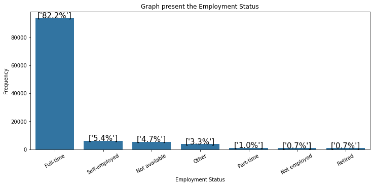

From this graph we can note that around 82% have a full time job

#### Income Range column

```
I am interesting to know what is the most common reange
```

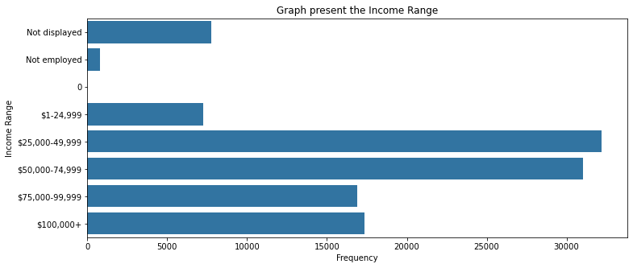

- Around 28% of people have income range between 25,000-49,999 and 27% have income range between 50,000-74,999

### The second thing we will explore columns related to the loan

#### Listing Category column

```
I am interesting to know where will the mony go for?
```

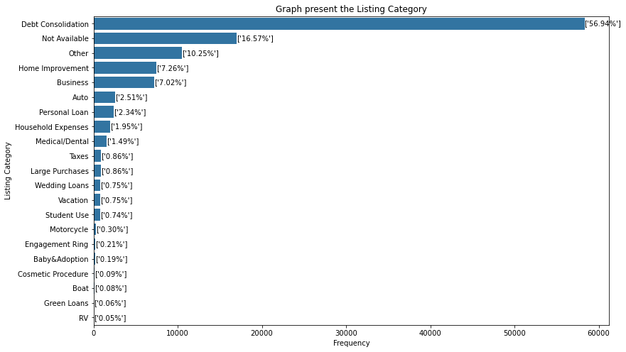

- Around 57% going to Debt Consolidation, 7.26% fro home improvement and 7.02% for business purpuse

#### Term column (The lenght of the loan per month)

```
I am interesting to know the peoples prefere to take a loan with how many months?
```

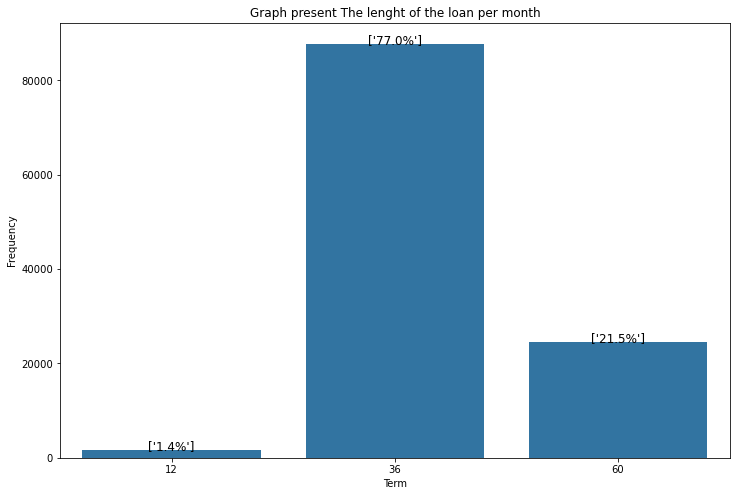

- We can notes from this graph that around 77% of people prefare to take a loan with 36 months

#### Loan Original Amount column

```
I am interesting to know what is the most frequently amount that people are interested to take it as a loan
```

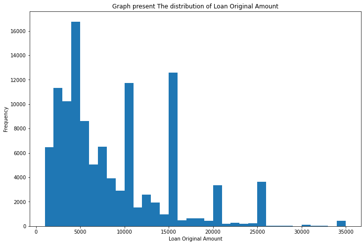

- The most of people are interested in taking loans with fixid amunt like 5K, 10K, 15K, and so on

### The third thing we will explore the credit Risk metrics

#### The prosper rating (alpha)

- I am interesting to know what is the prosper rating distribution
- here is a alink to get understand of the prosper rating [Link](https://www.prosper.com/invest/how-to-invest/prosper-ratings/?mod=article_inline)

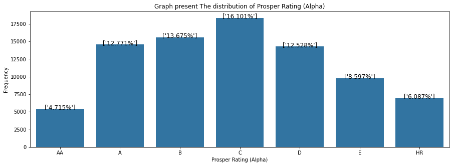

- Aroung 16% have a category C which is equal to 6.00–8.99%

#### The Borrower APR

- I am interesting to know what is the distribution of the borrower APR
- this link will be useful in understanding the meaning of borrower APR [Link](https://www.nerdwallet.com/article/mortgages/apr-annual-percentage-rate)

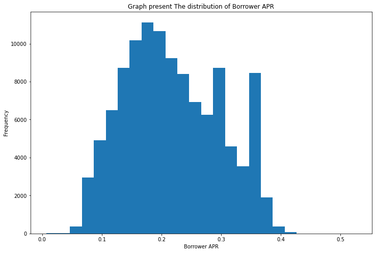

- The distribution is normaly and we have a beak around 0.2

## Conclusion about Univariate Exploration

### Discuss the distribution(s) of your variable(s) of interest. Were there any unusual points? Did you need to perform any transformations?

I performed some transformations like changing the column types to be categorical values for examble (TotalProsperLoans) and we notesed some outliers and we deal with them using axis lim() function

## Bivariate Exploration

In this section, we will investigate relationships between pairs of variables in dataset.

#### The relation between all numeric variables

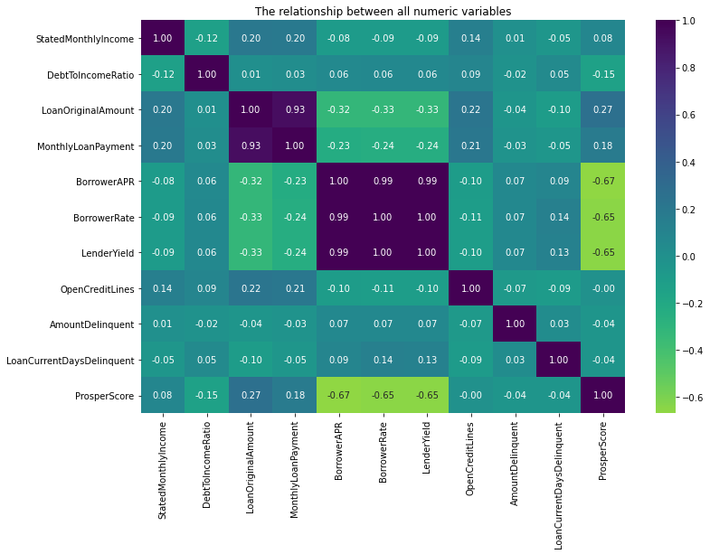

#### The relation between Borrower APR and Lender Yield

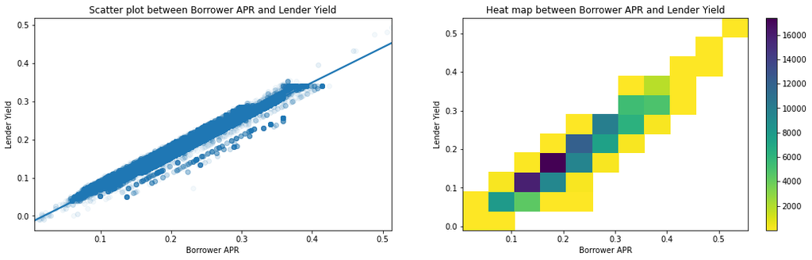

- The relation between Borrower APR and Lendr yield is strongly positive in poth heat map and scatter plot

#### The relation between Prosper Scoreand Borrower APR

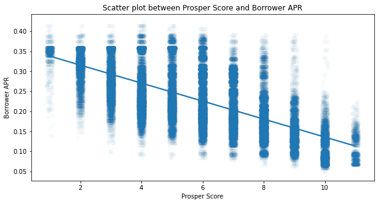

- We had a strongly negative relationship between Borrower APR and Prosper Score

#### The relation between Term (The length of the loan per month) and Borrower APR

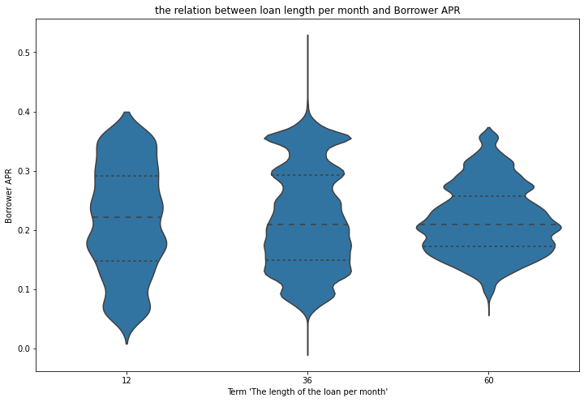

- 36 months loan has a wider range of Borrower APR but we need to focus more so we will apply the FacetGrid

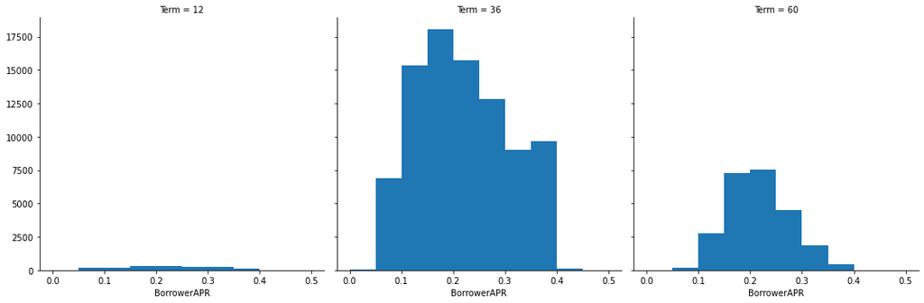

- Now it's look more clearly 36 months has the wider borrower APR and also has more frequency comparing with 12, 60 months

#### The relation between Employment status and Borrower APR

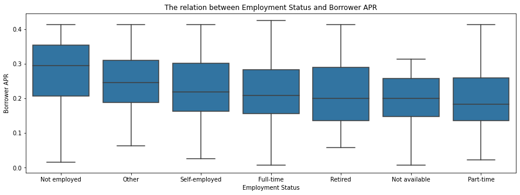

- Not employed has a lighest median and part-time has the lowest median full-time has the widest range in the Borrower APR

#### The relation between Income Range and Term

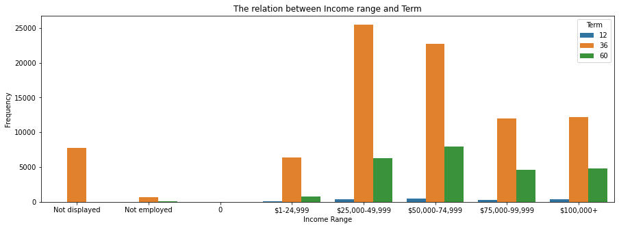

- In all income ranges people prefered to take a loan with 36 months

## Conclusion about Bivariate Exploration

### Talk about some of the relationships you observed in this part of the investigation. How did the feature(s) of interest vary with other features in the dataset?

- When Borrower APR increase the lender yield increase also.
- Borrower APR has strongly -ve relationship with prosper score
- 36 months loan term has the heighst frequency and wider Borrower APR range
- People prefer to take loan with 36 months term and it is not depend on the income range

### Did you observe any interesting relationships between the other features (not the main feature(s) of interest)?

- Peoples take loan for Debt consolidation more than any category
- Students take the lowest loan original amounts
- People with high monthly rate taking high loans

## Multivariate Exploration

Create plots of three or more variables to investigate your data even further. Make sure that your investigations are justified, and follow from your work in the previous sections.

#### The relation between Listing Category & Loan Original Amount & Term

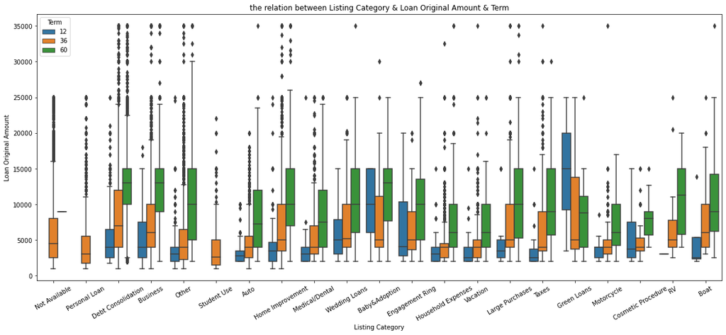

- It is interesting because the median of 12 months term of green loans category is higher than other two terms
- The reange of 12 months term in cosmetic procedure is largest than the other two terms
- Personal loan and student use loan taking 36 months terms only

#### The relation between Loan Status & Borrower APR & Employment Status

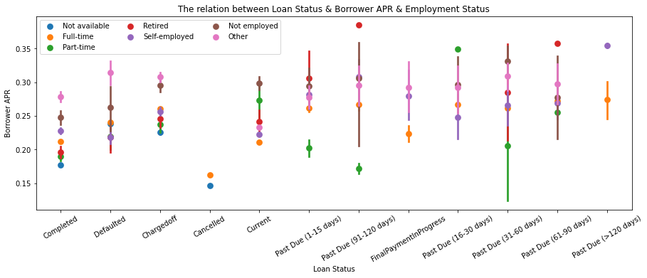

#### The relation between Borrower APR & Lender Yield & ProsperScore

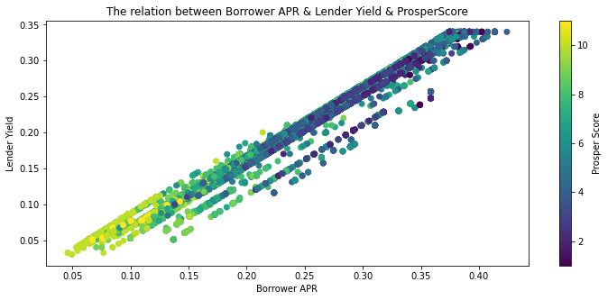

- This graph shows that the loans with higher Borrower APR and Lender yield had a lower prosper score.